# Exercise 6

Jai Broome

22 June, 2016

```r
require(knitr)
require(ggplot2)
require(kernlab)
require(SnowballC)
require(dplyr)
read_chunk("ex6_chunks.R")
```

# 1 Support Vector Machines

## 1.1 Example Dataset 1

```r
ex6data1 <- as.matrix(read.csv("../data/ex6data/ex6data1.csv"))
# x <- ex6data1[, 2:1]
```

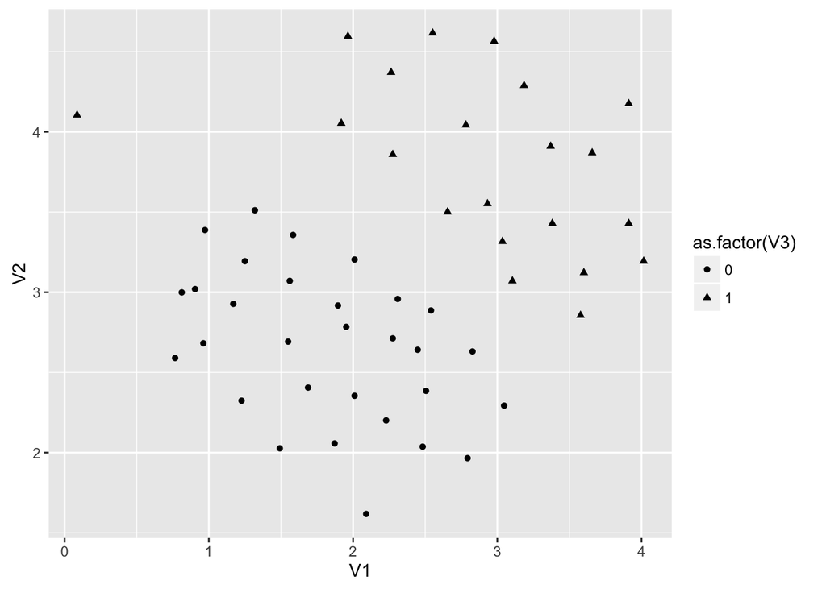

```r
g1 <- ggplot(data = as.data.frame(ex6data1), aes(V1, V2, shape = as.factor(V3))) +
    geom_point()
g1
```

```r
linSvm1 <- ksvm(V3 ~ V2 + V1,
                data = ex6data1,
                C = 1,
                type = "C-svc",
                kernel = "vanilladot",
                kpar = list(),
                scaled = F)
```

```r
decisionBoundary <- function(svm){
    w <- colSums(coef(svm)[[1]] * ex6data1[unlist(alphaindex(svm)), 2:1])
    b <- b(svm)
    C <- param(svm)[[1]]
    return(list(slope = -w[2]/w[1], intcpt = b/w[1], C = C))
}
```

**Still need to get the lines to color properly**

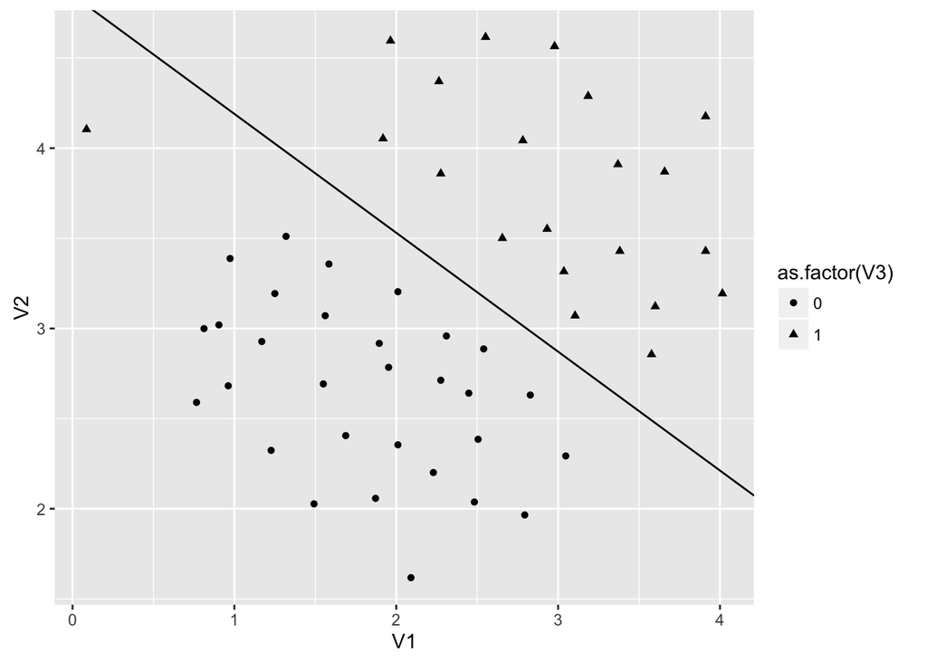

```r
bound1 <- decisionBoundary(linSvm1)
g2 <- g1 + geom_abline(intercept = bound1$intcpt,
                       slope = bound1$slope, aes(color = "c=1"))
g2
```

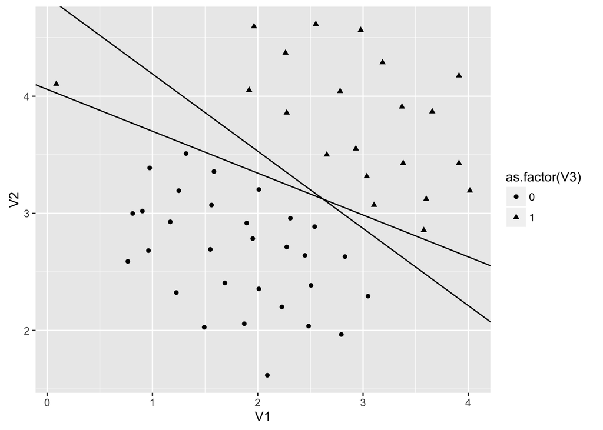

```r
linSvm2 <- ksvm(V3 ~ V2 + V1,
                data = ex6data1,
                C = 100,
                type = "C-svc",
                kernel = "vanilladot",
                kpar = list(),
                scaled = F)

bound2 <- decisionBoundary(linSvm2)
g3 <- g2 +
    geom_abline(intercept = bound2$intcpt,
                slope = bound2$slope, aes(color = "c=100")) +
  scale_colour_discrete("")
g3
```

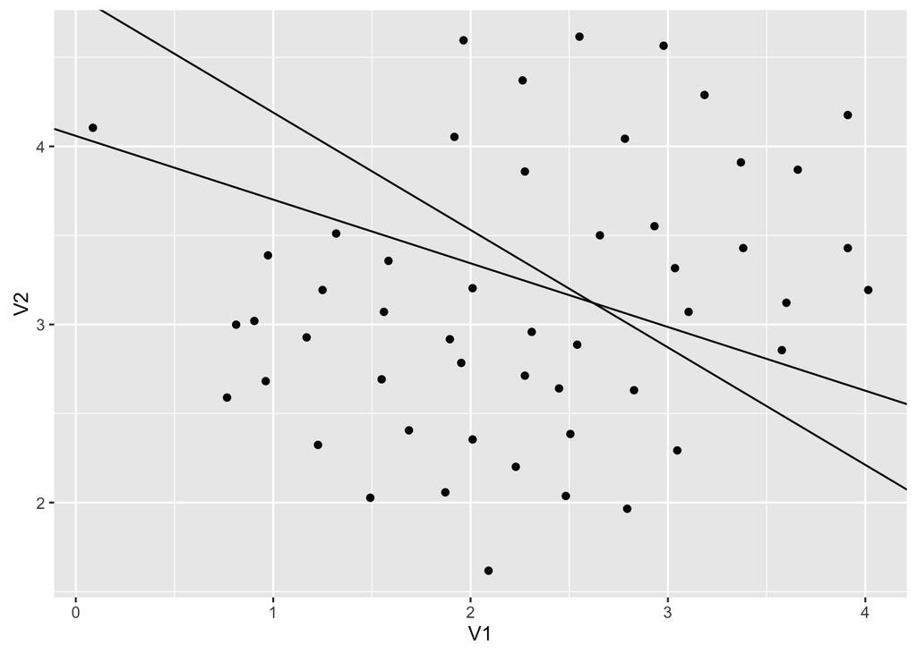

```r
ggplot(data = as.data.frame(ex6data1), aes(V1, V2)) + #, shape = as.factor(V3)
    geom_point() +
    geom_abline(intercept = bound1$intcpt,
                slope = bound1$slope, aes(color = "abcd")) +
    geom_abline(intercept = bound2$intcpt,
                slope = bound2$slope, aes(color = "xyz")) +
    scale_colour_discrete("")
```

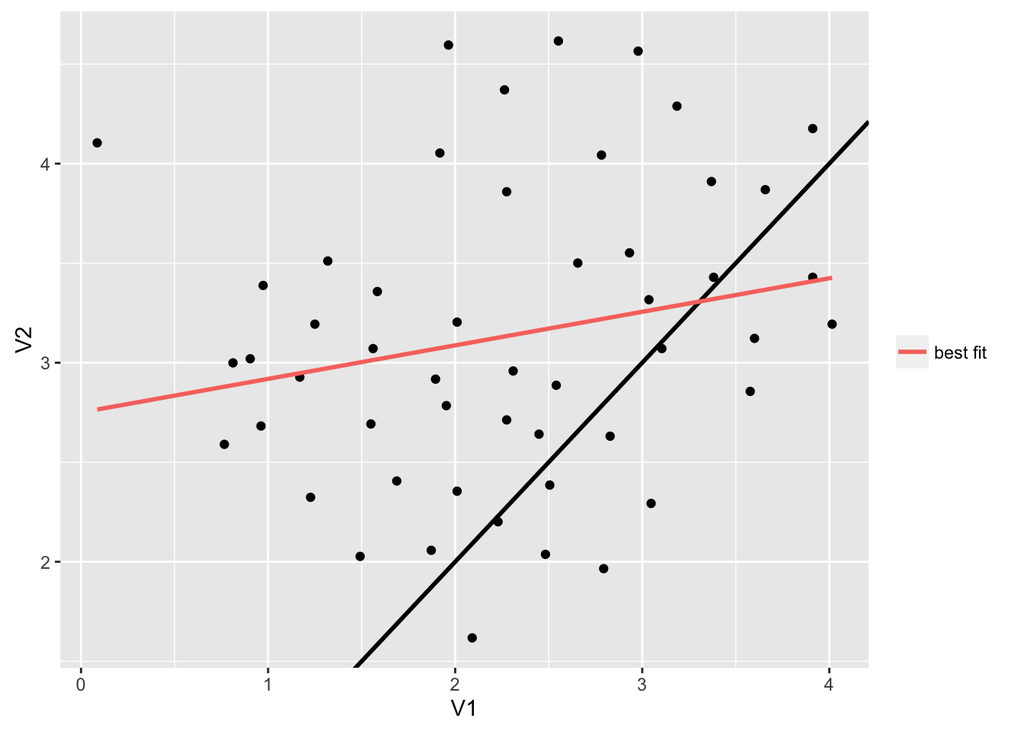

```r
ggplot(as.data.frame(ex6data1), aes(x = V1, y = V2)) +
  geom_point() +
  geom_abline(aes(colour="one-to-one"), intercept =0, slope = 1, size = 1) +
  stat_smooth(aes(colour="best fit"), method = "lm", se = FALSE, size = 1) +
  #facet_wrap(~ type) +
  scale_colour_discrete("")
```

## 1.2 SVM with Gaussian Kernels

### 1.2.1 Gaussian Kernel

I use the `ksvm` function from the `kernlab` package. One thing to note is that in order to use a custom kernel, I need to define a function that takes the hyperparameters from a `ksvm` call and generates a function that takes two vectors.

```r
gkGenerator <- function (sigma = 1) {
    gk <- function(Xi, Xj = NULL) {
        normSquared <- sum((Xi - Xj) ^ 2)
        # I'm not sure this needs to be coerced to a matrix, but rbfdot returns
        # a 1x1 matrix, so when in Rome...
        return(as.matrix(exp(-normSquared / (2 * sigma ^ 2))))
    }
    return(new("rbfkernel", .Data = gk, kpar = list(sigma = sigma)))
}
```

Because the built-in Gaussian kernel function in `kernlab` takes a different `sigma` parameter, I’ve defined a function that will make it comparable to the way it’s calculated in the assignment.

```r
sigTransform <- function(sigma){
    1 / (2 * sigma ^ 2)
}
```

```r
x1 <- c(1, 2, 1)
x2 = c(0, 4, -1)
sigma = 2
gk <- gkGenerator(sigma)
gk(x1, x2)
```

```
##           [,1]
## [1,] 0.3246525
```

```r
rbf <- rbfdot(sigTransform(sigma))
rbf(x1, x2)
```

```
##           [,1]
## [1,] 0.3246525
```

This should be about 0.324652. For good measure, I also checked the value using the `rbfdot` function built into `kernlab`.

### 1.2.2 Example Dataset 2

```r
ex6data2 <- as.matrix(read.csv("../data/ex6data/ex6data2.csv"))
# ex6data2 <- ex6data2[, c(2, 1, 3)]
```

```r
gkSvm <- ksvm(V3 ~ V2 + V1,
                data = ex6data2,
                C = 1,
                type = "C-svc",
                kernel = gkGenerator,
                kpar = list(sigma = sigTransform(0.1)),
                scaled = F)
gkSvm
```

```
## Support Vector Machine object of class "ksvm"
##
## SV type: C-svc  (classification)
##  parameter : cost C = 1
##
## Gaussian Radial Basis kernel function.
##  Hyperparameter : sigma =  50
##
## Number of Support Vectors : 185
##
## Objective Function Value : -116.6115
## Training error : 0.010429
```

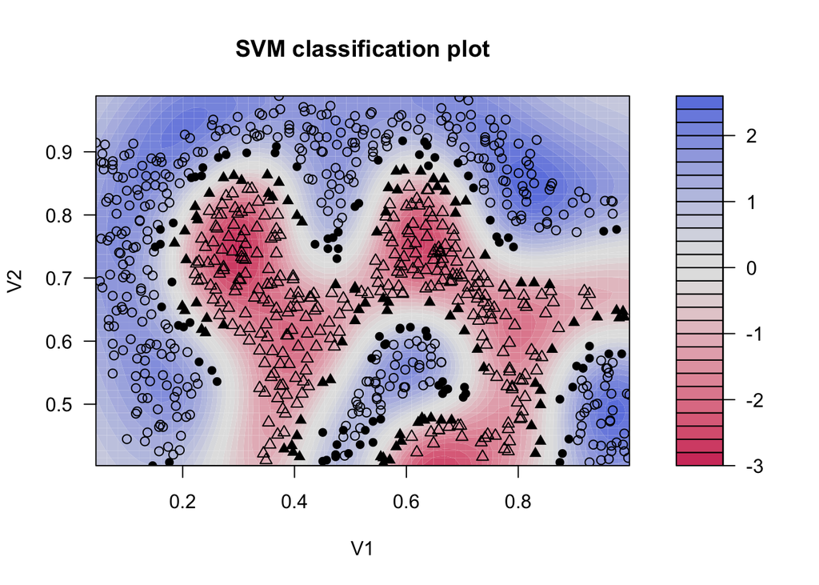

```r
# Note that the sigma value is different because of the transformation

plot(gkSvm, data = as.data.frame(ex6data2))
```

### 1.2.3 Example Dataset 3

```r
ex6data3_train <- as.matrix(read.csv("../data/ex6data/ex6data3_train.csv"))

ex6data3_val <- as.matrix(read.csv("../data/ex6data/ex6data3_val.csv"))
```

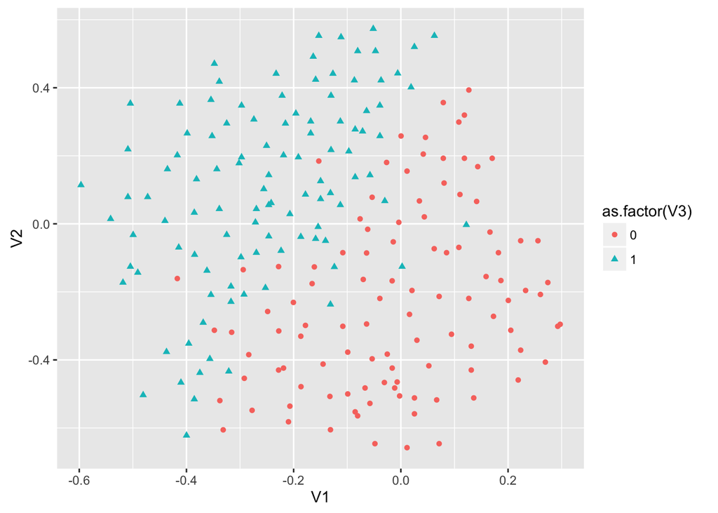

```r
g4 <- ggplot(as.data.frame(ex6data3_train), aes(V1, V2, shape = as.factor(V3),
                                                color = as.factor(V3))) +
    geom_point()
g4
```

Test all combination of `C` and `sigma` for the values 0.01, 0.03, 0.1, 0.3, 1, 3, 10, 30.

```r
testParams <- function(train, val, Cs, sigs){
    paramPerformance <- data.frame()
    for(C in Cs){
        for(sig in sigs){
            svm <- ksvm(V3 ~ .,
                           data = train,
                           C = C,
                           type = "C-svc",
                           kernel = gkGenerator,
                           kpar = list(sigma = sigTransform(sig)))
            pred <- predict(svm, val[, 1:ncol(val) - 1])
            valError <- sum(pred != val[, ncol(val)]) / length(pred)
            paramPerformance <- rbind(paramPerformance,
                                      c(C, sig, error(svm), valError))
        }
    }
    colnames(paramPerformance) <- c("C", "sigma", "train.error", "val.error")
    return(paramPerformance)
}
```

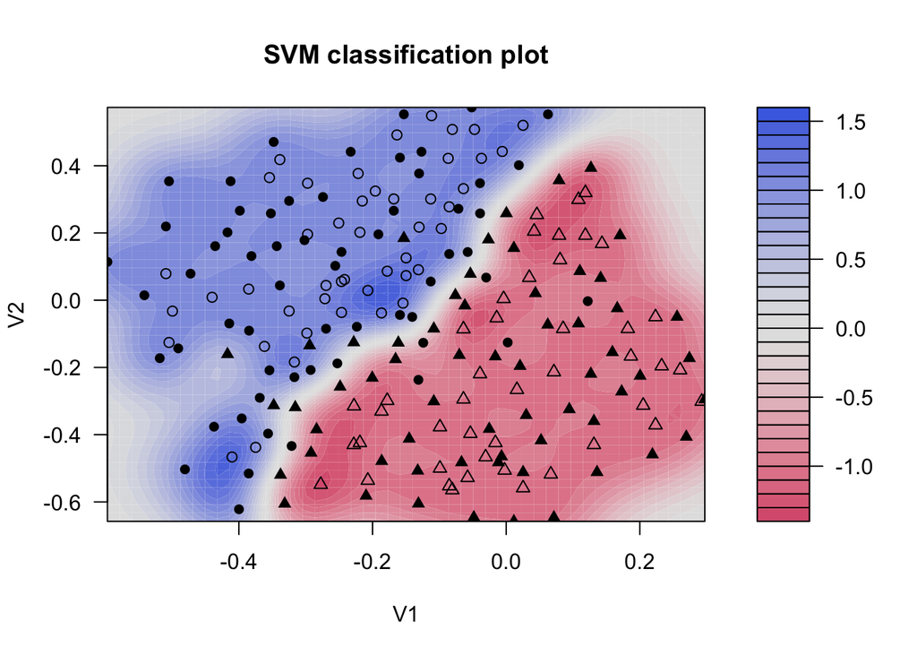

```r
v <- c(0.01, 0.03, 0.1, 0.3, 1, 3, 10, 30)
params3 <- testParams(ex6data3_train, ex6data3_val, v, v)
min.val.error <- params3[which.min(params3$val.error),]
svm3 <- ksvm(V3 ~ V2 + V1,
             data = ex6data3_train,
             C = min.val.error$C,
             type = "C-svc",
             kernel = gkGenerator,
             kpar = list(sigma = sigTransform(min.val.error$sigma)))
plot(svm3, data = as.data.frame(ex6data3_train))
```

# 2 Spam Classification

## 2.1 Preprocessing Emails

Sample email

```r
con <- file("../data/ex6data/emailSample1.txt", open = "r")
lines <- readLines(con)
close(con)
writeLines(lines)
```

```
## > Anyone knows how much it costs to host a web portal ?
## >
## Well, it depends on how many visitors you're expecting.
## This can be anywhere from less than 10 bucks a month to a couple of $100.
## You should checkout http://www.rackspace.com/ or perhaps Amazon EC2
## if youre running something big..
##
## To unsubscribe yourself from this mailing list, send an email to:
## groupname-unsubscribe@egroups.com
```

```r
sampleEmail1 <- paste(lines, collapse = " ")
sampleEmail1
```

```
## [1] "> Anyone knows how much it costs to host a web portal ? > Well, it depends on how many visitors you're expecting. This can be anywhere from less than 10 bucks a month to a couple of $100.  You should checkout http://www.rackspace.com/ or perhaps Amazon EC2  if youre running something big..  …
```

```r
preProcess <- function(email){
    email <- tolower(email)
    email <- gsub('<[^<>]+>', ' ', email)
    email <- gsub('[0-9]+', 'number', email)
    email <- gsub("(http|https)://[^[:space:]]+", ' httpaddr', email)
    email <- gsub('[^[:space:]]+@[^[:space:]]+', 'emailaddr', email)
    email <- gsub('[$]+', 'dollar', email)
    email <- gsub("'", "", email) #prevent contractions from becoming 2 words
    email <- gsub("[[:punct:]]+", " ", email)
    # wordStem requires a vector of words
    email <- strsplit(email, " ")[[1]]
    email <- wordStem(email)
    # # remove empty elements
    email <- email[email != ""]
    return(email)
}
```

```r
e1Processed <- preProcess(sampleEmail1)
e1Processed
```

```
##  [1] "anyon"      "know"       "how"        "much"       "it"
##  [6] "cost"       "to"         "host"       "a"          "web"
## [11] "portal"     "well"       "it"         "depend"     "on"
## [16] "how"        "mani"       "visitor"    "your"       "expect"
## [21] "thi"        "can"        "be"         "anywher"    "from"
## [26] "less"       "than"       "number"     "buck"       "a"
## [31] "month"      "to"         "a"          "coupl"      "of"
## [36] "dollarnumb" "you"        "should"     "checkout"   "httpaddr"
## [41] "or"         "perhap"     "amazon"     "ecnumb"     "if"
## [46] "your"       "run"        "someth"     "big"        "to"
## [51] "unsubscrib" "yourself"   "from"       "thi"        "mail"
## [56] "list"       "send"       "an"         "email"      "to"
## [61] "emailaddr"
```

### 2.1.1 Vocabulary List

```r
vocabIndex <- function(procEmail, vocab){
    index <- sapply(procEmail, FUN = function(x){match(x, vocab)})
    index <- index[!is.na(index)]
    return(index)
}
```

```r
emailVocab <- read.table("../data/ex6data/vocab.txt", sep = "\t")
sampleIndexed <- vocabIndex(e1Processed, emailVocab[, 2])
sampleIndexed
```

```
##      anyon       know        how       much         it       cost
##         86        916        794       1077        883        370
##         to       host        web       well         it     depend
##       1699        790       1822       1831        883        431
##         on        how       mani       your     expect        thi
##       1171        794       1002       1895        592       1676
##        can         be    anywher       from       less       than
##        238        162         89        688        945       1663
##     number      month         to      coupl         of dollarnumb
##       1120       1062       1699        375       1162        479
##        you     should   httpaddr         or     perhap         if
##       1893       1510        799       1182       1237        810
##       your        run     someth        big         to unsubscrib
##       1895       1440       1547        181       1699       1758
##   yourself       from        thi       mail       list       send
##       1896        688       1676        992        961       1477
##         an      email         to  emailaddr
##         71        530       1699        531
```

“Visitor” is left out of the supplied vocabulary, which is why there are only 44 non-zero entries. I’m not sure why it was included in the homework print out. It doesn’t seem to be a stemming implementation problem since “visitors” is successfully shortened to “visitor”, but there isn’t an entry for it in the vocabulary.

```r
wordInIndex <- function(x, index){x %in% index}

emailFeatures <- function(email, vocab){
    index <- as.vector(vocabIndex(email, vocab[, 2]))
    features <- sapply(vocab[, 1], FUN = function(x){wordInIndex(x, index)})
    return(features)
}
```

```r
e1Features <- emailFeatures(e1Processed, emailVocab)
str(e1Features)
```

```
##  logi [1:1899] FALSE FALSE FALSE FALSE FALSE FALSE ...
```

```r
sum(e1Features)
```

```
## [1] 44
```

## 2.2 Training SVM for Spam Classification

```r
spamTrain <- read.csv("../data/ex6data/spamTrain.csv")
spamTest <- read.csv("../data/ex6data/spamTest.csv")
```

```r
spamSvm <- ksvm(V1900 ~ .,
                data = spamTrain,
                C = 0.1,
                type = "C-svc",
                kernel = "vanilladot",
                scaled = F)
spamPredict <- predict(spamSvm, spamTest[, 1:(ncol(spamTest) - 1)])
testAccuracy <- (sum(spamPredict==spamTest[, ncol(spamTest)])) /
    length(spamPredict)
```

In sample accuracy is 99.825% and out of sample accuracy is 98.9%.

## 2.3 Top Predictors for Spam

```r
topPredictors <- as.data.frame(cbind(spamSvm@alphaindex[[1]],
                                     spamSvm@coef[[1]]))
topPredictors <-  arrange(topPredictors, desc(V2))
emailVocab[topPredictors[1:15, 1],]
```

```
##        V1        V2
## 358   358   control
## 565   565     estim
## 654   654      five
## 674   674    former
## 740   740     guess
## 772   772 helvetica
## 885   885    itself
## 956   956      like
## 993   993    mailer
## 995   995  maintain
## 1250 1250    pictur
## 1287 1287       pre
## 1464 1464    second
## 1570 1570     speed
## 1602 1602  structur
```

There were more highly predictive words for spam, but these are the first 15.